# Part_II_slide_deck_template slides

## Part II - Slide_deck_Template

## by Maurício de Assis Domingues

## Investigation Overview

I am interested in collecting information related to travel time and the relationship with gender, age, customer or subscriber. Analyze variables and look for correlations between distributions, collect information and generate insights about the dataframe. Check how the system works and collect relevant information for the analysis of the bike sharing system and how the public that uses this means of transport is formed.

## Dataset Overview

This data set includes information about individual rides made in a bike-sharing system covering the greater San Francisco Bay area. The Bike Share for All Trip bike-sharing system was launched by Ford GoBike in the San Francisco Bay Area in 2017 in partnership with the Metropolitan Transportation Commission and Bay Area Bike Share. .

## 1 - Days of week with more users

Thursdays have the highest number of users, followed by Tuesdays and Wednesdays.

```
Text(0.5,1,'Days of the week with more users')
```

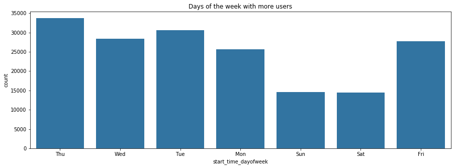

# 2 - Hours throught the day with more users

Throughout the day, we have two peaks in the use of bikes. The first takes place around 8 am and the second at 5 pm.

```
Text(0.5,1,'Hours throughout the day with more users')
```

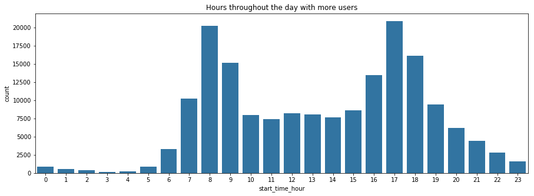

## 3 - Distribution between age and duration of trip

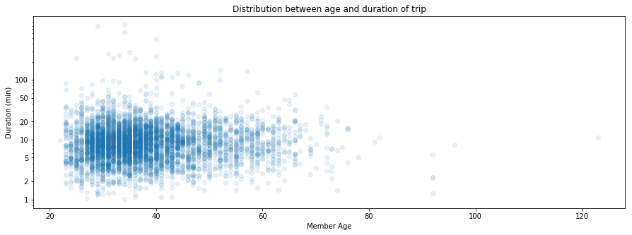

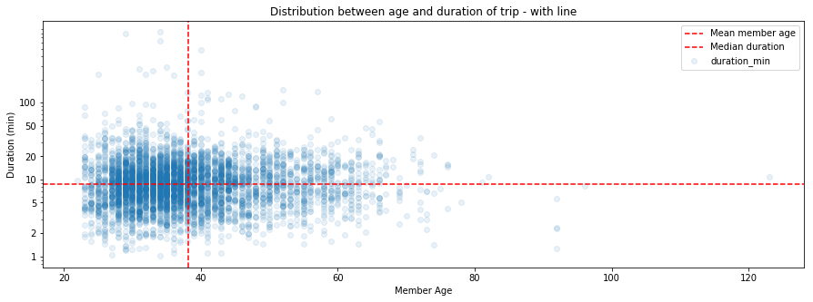

## 4 - Distribution between age and gender

The correlation between age and gender presents some peculiarities: male presents a distribution that increases up to 25 years old and, in sequence, an arc that decreases at first and then increases again up to 30 years old, from this point onwards there is a smooth reduction up to 40 years old years of age and in the strongest sequence up to 60 years of age; Females, on the other hand, grow progressively up to 27 years of age and then start a smooth decline up to 41 years of age, increasing in level up to 60 years of age with some variations between 50 and 55 years of age; Others show a strong increase up to 30 and then decrease to 44, showing a growth again up to 55 and then decrease up to 60.years.

```
Text(0.5,1,'Distribution between Age and Gender')
```

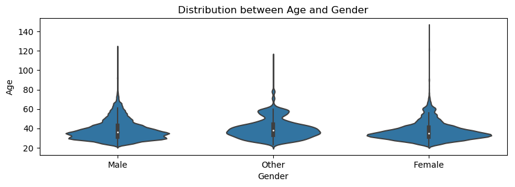